# Initial EDA

Rayan Abumansi

2024-06-18

## 2. Packages and Data

```r
#load libraries
library(tidyverse)
library(ggplot2)
library(dplyr)


#load data

#Data set 1
coffee_quality <- read_csv("df_arabica_clean.csv")
head(coffee_quality)
```

| ...1 | ID | Country of Origin | Farm Name | Lot Number | Mill | ICO Number | Company | Altitude | Region | Producer | Number of Bags | Bag Weight | In-Country Partner | Harvest Year | Grading Date | Owner | Variety | Status | Processing Method | Aroma | Flavor | Aftertaste | Acidity | Body | Balance | Uniformity | Clean Cup | Sweetness | Overall | … |
| --- | --- | --- | --- | --- | --- | --- | --- | --- | --- | --- | --- | --- | --- | --- | --- | --- | --- | --- | --- | --- | --- | --- | --- | --- | --- | --- | --- | --- | --- | --- |
| 0 | 0 | Colombia | Finca El Paraiso | CQU2022015 | Finca El Paraiso | NA | Coffee Quality Union | 1700-1930 | Piendamo,Cauca | Diego Samuel Bermudez | 1 | 35 kg | Japan Coffee Exchange | 2021 / 2022 | September 21st, 2022 | Coffee Quality Union | Castillo | Completed | Double Anaerobic Washed | 8.58 | 8.50 | 8.42 | 8.58 | 8.25 | 8.42 | 10 | 10 | 10 | 8.58 | … |
| 1 | 1 | Taiwan | Royal Bean Geisha Estate | The 2022 Pacific Rim Coffee Summit,T037 | Royal Bean Geisha Estate | NA | Taiwan Coffee Laboratory | 1200 | Chiayi | 曾福森 | 1 | 80 kg | Taiwan Coffee Laboratory 台灣咖啡研究室 | 2021 / 2022 | November 15th, 2022 | Taiwan Coffee Laboratory 台灣咖啡研究室 | Gesha | Completed | Washed / Wet | 8.50 | 8.50 | 7.92 | 8.00 | 7.92 | 8.25 | 10 | 10 | 10 | 8.50 | … |
| 2 | 2 | Laos | OKLAO coffee farms | The 2022 Pacific Rim Coffee Summit,LA01 | oklao coffee processing plant | NA | Taiwan Coffee Laboratory | 1300 | Laos Borofen Plateau | WU TAO CHI | 19 | 25 kg | Taiwan Coffee Laboratory 台灣咖啡研究室 | 2021 / 2022 | November 15th, 2022 | Taiwan Coffee Laboratory 台灣咖啡研究室 | Java | Completed | Semi Washed | 8.33 | 8.42 | 8.08 | 8.17 | 7.92 | 8.17 | 10 | 10 | 10 | 8.33 | … |
| 3 | 3 | Costa Rica | La Cumbre | CQU2022017 | La Montana Tarrazu MIll | NA | Coffee Quality Union | 1900 | Los Santos,Tarrazu | Santa Maria de Dota | 1 | 22 kg | Japan Coffee Exchange | 2022 | September 21st, 2022 | Coffee Quality Union | Gesha | Completed | Washed / Wet | 8.08 | 8.17 | 8.17 | 8.25 | 8.17 | 8.08 | 10 | 10 | 10 | 8.25 | … |
| 4 | 4 | Colombia | Finca Santuario | CQU2023002 | Finca Santuario | NA | Coffee Quality Union | 1850-2100 | Popayan,Cauca | Camilo Merizalde | 2 | 24 kg | Japan Coffee Exchange | 2022 | March 6th, 2023 | Coffee Quality Union | Red Bourbon | Completed | Honey,Mossto | 8.33 | 8.33 | 8.08 | 8.25 | 7.92 | 7.92 | 10 | 10 | 10 | 8.25 | … |
| 5 | 5 | Guatemala | La Colina | The 2022 Pacific Rim Coffee Summit,GT02 | Dinámica Café | NA | Taiwan Coffee Laboratory | 1668 | Chimaltenango | Emilio Antonio Medina Garcia | 5 | 30 kg | Taiwan Coffee Laboratory 台灣咖啡研究室 | 2022 | November 15th, 2022 | Taiwan Coffee Laboratory 台灣咖啡研究室 | Gesha | Completed | Washed / Wet | 8.33 | 8.33 | 8.25 | 7.83 | 7.83 | 8.17 | 10 | 10 | 10 | 8.25 | … |

```r
#Data set 2
coffee_reviews_price <- read_csv("reviews_feb_2023.csv")
head(coffee_reviews_price)
```

| title | rating | acidity_structure | aftertaste | aroma | body | flavor | with_milk | agtron | blind_assessment | bottom_line | coffee_origin | est_price | notes | review_date | roast_level | roaster | roaster_location | url |
| --- | --- | --- | --- | --- | --- | --- | --- | --- | --- | --- | --- | --- | --- | --- | --- | --- | --- | --- |
| Bolivia Manantial Gesha | 93 | 9 | 8 | 9 | 8 | 9 | NA | 60/78 | Richly aromatic, floral-toned. Magnolia, cocoa nib, cane sugar, red plum, nutmeg in aroma and cup. Elegantly sweet structure with delicate, bright acidity; silky, vibrant mouthfeel. Flavor-saturated f… | This washed Boliva Gesha has all the aromatics you’d expect from the variety and is from an under-the-radar origin worth seeking out — a value for its type. | Caranavi, Bolivia | $30.00/12 ounces | Produced by Angel Mamani Chambi, entirely of the Geisha (also spelled Gesha) variety of Arabica, and processed by the traditional washed method (fruit skin and pulp are removed before drying). Establi… | January 2023 | Medium-Light | Red Rooster Coffee Roaster | Floyd, Virginia | https://www.coffeereview.com/review/bolivia-manantial-gesha/ |
| Yellow Pacamara Carbonic Maceration Nanolot | 92 | 8 | 8 | 9 | 8 | 9 | NA | 60/78 | Crisply sweet-savory. White peach, hop flowers, cocoa powder, pineapple kefir, fir in aroma and cup. Sweetly savory structure with brisk acidity; crisp, velvety mouthfeel. The finish consolidates to n… | A carbonic-macerated Yellow Pacamara grown in Nicaragua that’s equal parts sweet (stone fruit and cocoa) and savory (hops and aromatic wood). | Matagalpa growing region, Nicaragua | $160.00/12 ounces | Produced by Benjamin Weiner at Finca Idealista entirely of the Yellow Pacamara variety of Arabica, and processed by the carbonic maceration method, which involves fermenting whole coffee fruit inside … | December 2022 | Medium-Light | Eccentricity Coffee Co. | Cleveland, Ohio | https://www.coffeereview.com/review/brix-breaker-yellow-pacamara-carbonic-maceration-nanolot/ |
| Ethiopia Gera Genji Challa | 94 | 9 | 8 | 9 | 9 | 9 | NA | 59/77 | Delicately aromatic, complex. Lilac, cocoa nib, pink grapefruit zest, shishito pepper, apricot in aroma and cup. Sweetly tart with juicy, bright acidity; plush, syrupy-smooth mouthfeel. Floral finish … | A nuanced, multilayered washed Ethiopia cup with spicy floral notes at its center and a throughline of cocoa nib. | Agaro Gera, Jimma Zone, Oromia State, Ethiopia | $28.00/12 ounces | Ethiopia coffees like this one are largely produced largely from traditional indigenous landrace varieties of Arabica. Produced by smallholding members of the Nano Challa Cooperative and processed by … | December 2022 | Medium-Light | Mostra Coffee | San Diego, California | https://www.coffeereview.com/review/ethiopia-gera-genji-challa/ |
| Yirgacheffe Mengesha Natural | 94 | 9 | 8 | 9 | 9 | 9 | NA | 60/77 | High-toned, fruit-driven. Boysenberry, pear, cocoa nib, tangerine zest, pink peppercorn in aroma and cup. Sweetly tart structure with juicy-bright acidity; crisp, velvety mouthfeel. The finish consoli… | A fruit medley in a cup — think boysenberry and fresh pear — with a crisp cocoa throughline. | Yirgacheffe growing region, southern Ethiopia | $20.50/12 ounces | Produced at Mengesha Farm from selections of indigenous landrace varieties of Arabica long grown in the region, and processed by the natural method (dried in the whole fruit). With more than 10 years … | November 2022 | Medium-Light | Regent Coffee | Glendale, California | https://www.coffeereview.com/review/yirgacheffe-mengesha-natural/ |
| Tropical Summer Colombia La Sierra | 93 | 9 | 8 | 9 | 8 | 9 | NA | 60/77 | Fruit-driven, crisply chocolaty. Goji berry, dried plum, baking chocolate, amber, narcissus in aroma and cup. Crisply sweet structure with balanced acidity; lightly satiny mouthfeel. Fruit-toned finis… | An experimentally processed Colombia, sweetly fruit-forward with ballast from crisp chocolate notes. | La Sierra, Cauca Department, Colombia | $18.99/8 ounces | Produced by smallholding farmers from trees of the Castillo, Caturra, Pajarito, Tabi and Bourbon varieties of Arabica, and processed by the traditional washed method using species of lactic acid-produ… | November 2022 | Medium-Light | Merge Coffee Company | Harrisonburg, Virginia | https://www.coffeereview.com/review/tropical-summer-colombia-la-sierra/ |
| The Glistening Orchard Blend | 91 | 7 | 8 | 9 | 8 | 9 | NA | 58/77 | Fruity and crisply chocolaty. Green banana, cane sugar, dark chocolate, cedar, cashew in aroma and cup. Sweetly tart with sharp acidity; full, velvety mouthfeel. The finish consolidates to notes of ch… | A uniquely composed blend of two Colombia fruit-fermented washed coffees combined with a traditionally washed Ethiopia — chocolaty and tart-leaning. | Colombia; Ethiopia | NT $459/8 ounces | A blend of three coffees — a washed coffee fermented with pineapple and another fermented with passionfruit from Colombia and a traditional washed from Ethiopia. Buon Caffe is a specialty coffee roast… | November 2022 | Medium-Light | Buon Caffe | Taipei, Taiwan | https://www.coffeereview.com/review/the-glistening-orchard-blend/ |

```r
NA
```

## 3. Data Exploration

### Data set 1: Coffee Quality Data

*Purpose: The data is collected by the Coffee Quality Institute (CQI) to evaluate coffee quality using professional cupping scores.*

```r
#summary
summary(coffee_quality)
```

```
      ...1             ID        Country of Origin   Farm Name          Lot Number
 Min.   :  0.0   Min.   :  0.0   Length:207         Length:207         Length:207
 1st Qu.: 51.5   1st Qu.: 51.5   Class :character   Class :character   Class :character
 Median :103.0   Median :103.0   Mode  :character   Mode  :character   Mode  :character
 Mean   :103.0   Mean   :103.0
 3rd Qu.:154.5   3rd Qu.:154.5
 Max.   :206.0   Max.   :206.0
     Mill            ICO Number          Company            Altitude            Region
 Length:207         Length:207         Length:207         Length:207         Length:207
 Class :character   Class :character   Class :character   Class :character   Class :character
 Mode  :character   Mode  :character   Mode  :character   Mode  :character   Mode  :character



   Producer         Number of Bags    Bag Weight        In-Country Partner Harvest Year
 Length:207         Min.   :   1.0   Length:207         Length:207         Length:207
 Class :character   1st Qu.:   1.0   Class :character   Class :character   Class :character
 Mode  :character   Median :  14.0   Mode  :character   Mode  :character   Mode  :character
                    Mean   : 155.4
                    3rd Qu.: 275.0
                    Max.   :2240.0
 Grading Date          Owner             Variety             Status          Processing Method
 Length:207         Length:207         Length:207         Length:207         Length:207
 Class :character   Class :character   Class :character   Class :character   Class :character
 Mode  :character   Mode  :character   Mode  :character   Mode  :character   Mode  :character



     Aroma           Flavor        Aftertaste      Acidity           Body          Balance
 Min.   :6.500   Min.   :6.750   Min.   :6.67   Min.   :6.830   Min.   :6.830   Min.   :6.670
 1st Qu.:7.580   1st Qu.:7.580   1st Qu.:7.42   1st Qu.:7.500   1st Qu.:7.500   1st Qu.:7.500
 Median :7.670   Median :7.750   Median :7.58   Median :7.670   Median :7.670   Median :7.670
 Mean   :7.721   Mean   :7.745   Mean   :7.60   Mean   :7.690   Mean   :7.641   Mean   :7.644
 3rd Qu.:7.920   3rd Qu.:7.920   3rd Qu.:7.75   3rd Qu.:7.875   3rd Qu.:7.750   3rd Qu.:7.790
 Max.   :8.580   Max.   :8.500   Max.   :8.42   Max.   :8.580   Max.   :8.250   Max.   :8.420
   Uniformity      Clean Cup    Sweetness     Overall         Defects  Total Cup Points
 Min.   : 8.67   Min.   :10   Min.   :10   Min.   :6.670   Min.   :0   Min.   :78.00
 1st Qu.:10.00   1st Qu.:10   1st Qu.:10   1st Qu.:7.500   1st Qu.:0   1st Qu.:82.58
 Median :10.00   Median :10   Median :10   Median :7.670   Median :0   Median :83.75
 Mean   : 9.99   Mean   :10   Mean   :10   Mean   :7.677   Mean   :0   Mean   :83.71
 3rd Qu.:10.00   3rd Qu.:10   3rd Qu.:10   3rd Qu.:7.920   3rd Qu.:0   3rd Qu.:84.83
 Max.   :10.00   Max.   :10   Max.   :10   Max.   :8.580   Max.   :0   Max.   :89.33
 Moisture Percentage Category One Defects    Quakers           Color           Category Two Defects
 Min.   : 0.00       Min.   :0.0000       Min.   : 0.0000   Length:207         Min.   : 0.000
 1st Qu.:10.10       1st Qu.:0.0000       1st Qu.: 0.0000   Class :character   1st Qu.: 0.000
 Median :10.80       Median :0.0000       Median : 0.0000   Mode  :character   Median : 1.000
 Mean   :10.74       Mean   :0.1353       Mean   : 0.6908                      Mean   : 2.251
 3rd Qu.:11.50       3rd Qu.:0.0000       3rd Qu.: 1.0000                      3rd Qu.: 3.000
 Max.   :13.50       Max.   :5.0000       Max.   :12.0000                      Max.   :16.000
  Expiration        Certification Body Certification Address Certification Contact
 Length:207         Length:207         Length:207            Length:207
 Class :character   Class :character   Class :character      Class :character
 Mode  :character   Mode  :character   Mode  :character      Mode  :character
```

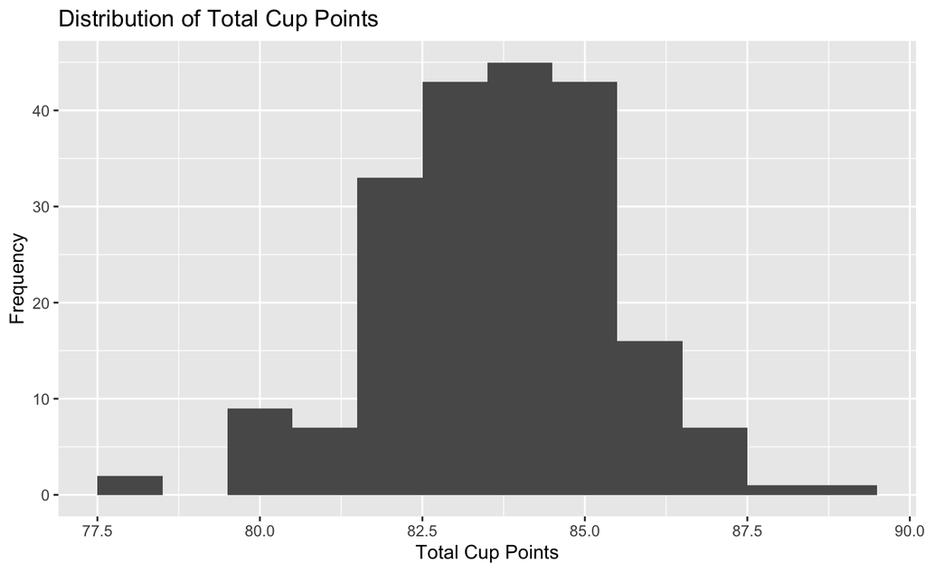

```r
#histogram
ggplot(coffee_quality, aes(x = `Total Cup Points`)) +
  geom_histogram(binwidth = 1) +
  labs(title = "Distribution of Total Cup Points", x = "Total Cup Points", y = "Frequency")
```

```r
#check for missing values
sum(is.na(coffee_quality))
```

```
[1] 153
```

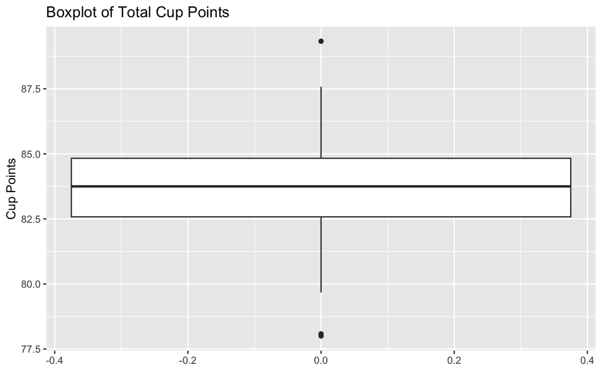

```r
#Boxplot
ggplot(coffee_quality, aes(y = `Total Cup Points`)) +
  geom_boxplot() +
  labs(title = "Boxplot of Total Cup Points", y = "Cup Points")
```

### Data set 2: Consumer Ratings and Reviews

*Purpose: The data is collected from CoffeeReview.com, which summarizes consumer ratings and reviews.*

```r
summary(coffee_reviews_price)
```

```
    title               rating      acidity_structure   aftertaste         aroma             body
 Length:7041        Min.   :52.00   Min.   : 1.000    Min.   : 2.000   Min.   : 2.000   Min.   : 4.000
 Class :character   1st Qu.:90.00   1st Qu.: 8.000    1st Qu.: 8.000   1st Qu.: 8.000   1st Qu.: 8.000
 Mode  :character   Median :92.00   Median : 9.000    Median : 8.000   Median : 9.000   Median : 8.000
                    Mean   :90.87   Mean   : 8.488    Mean   : 7.969   Mean   : 8.362   Mean   : 8.095
                    3rd Qu.:93.00   3rd Qu.: 9.000    3rd Qu.: 8.000   3rd Qu.: 9.000   3rd Qu.: 9.000
                    Max.   :98.00   Max.   :10.000    Max.   :10.000   Max.   :10.000   Max.   :10.000
                    NA's   :4       NA's   :4875      NA's   :872      NA's   :51       NA's   :12
     flavor        with_milk            agtron          blind_assessment   bottom_line
 Min.   : 1.000   Length:7041        Length:7041        Length:7041        Length:7041
 1st Qu.: 8.000   Class :character   Class :character   Class :character   Class :character
 Median : 9.000   Mode  :character   Mode  :character   Mode  :character   Mode  :character
 Mean   : 8.447
 3rd Qu.: 9.000
 Max.   :10.000
 NA's   :17
 coffee_origin       est_price            notes           review_date        roast_level
 Length:7041        Length:7041        Length:7041        Length:7041        Length:7041
 Class :character   Class :character   Class :character   Class :character   Class :character
 Mode  :character   Mode  :character   Mode  :character   Mode  :character   Mode  :character




   roaster          roaster_location       url
 Length:7041        Length:7041        Length:7041
 Class :character   Class :character   Class :character
 Mode  :character   Mode  :character   Mode  :character
```

## 4. Cleaning Data (Data set 2)

*Data set 2 has a lot of (country of origin) regarding coffee and reviews, so I will only use ones that are available from the data set 1 to have better insights regarding coffee quality*

```r
#unique countries of origin from Data set 1
countries_of_origin <- unique(coffee_quality$`Country of Origin`)

#clean and filter from Dataset 2
coffee_reviews_price_clean <- coffee_reviews_price %>%
  mutate(coffee_origin = str_replace_all(coffee_origin, " ;", ",")) %>%
  separate_rows(coffee_origin, sep = ",") %>%
  mutate(coffee_origin = str_trim(coffee_origin)) %>%
  filter(coffee_origin %in% countries_of_origin)

unique(coffee_reviews_price_clean$coffee_origin)
```

```
 [1] "Nicaragua"   "Ethiopia"    "Colombia"    "Guatemala"   "Costa Rica"  "Brazil"      "Peru"
 [8] "Taiwan"      "Panama"      "El Salvador" "Kenya"       "Indonesia"   "Mexico"      "Vietnam"
[15] "Honduras"    "Uganda"      "Thailand"    "Madagascar"  "Myanmar"
```

```r
#In the price column from data set 2, price is not constant

#filter out rows with prices not in USD
coffee_reviews_price_clean <- coffee_reviews_price_clean %>%
  filter(str_detect(est_price, "\\$")) %>%
  mutate(est_price_numeric = as.numeric(gsub("[$,]", "", str_extract(est_price, "\\$[0-9,.]+"))))

#remove NA values in est_price_numeric
coffee_reviews_price_clean <- coffee_reviews_price_clean %>%
  filter(!is.na(est_price_numeric))

#remove extreme outliers
coffee_reviews_price_clean <- coffee_reviews_price_clean %>%
  filter(est_price_numeric < 1000)
```

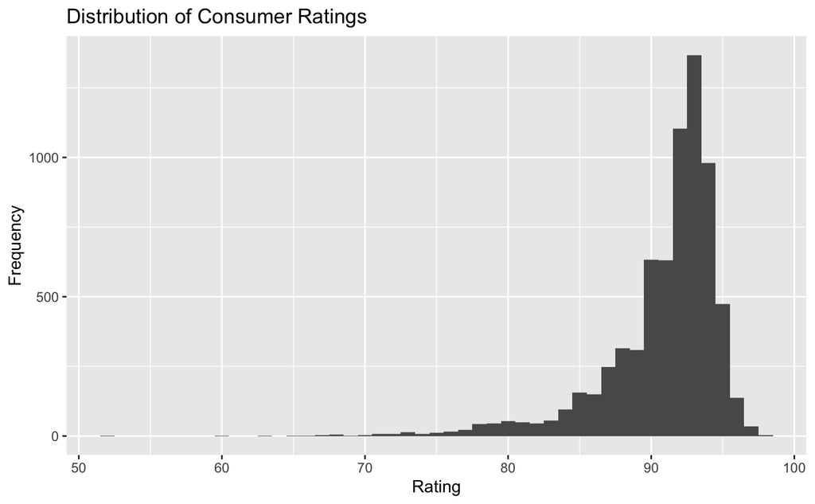

```r
#Histogram for Ratings
ggplot(coffee_reviews_price, aes(x = rating)) +
  geom_histogram(binwidth = 1) +
  labs(title = "Distribution of Consumer Ratings", x = "Rating", y = "Frequency")
```

```r
#check for missing values
sum(is.na(coffee_reviews_price))
```

```
[1] 18885
```

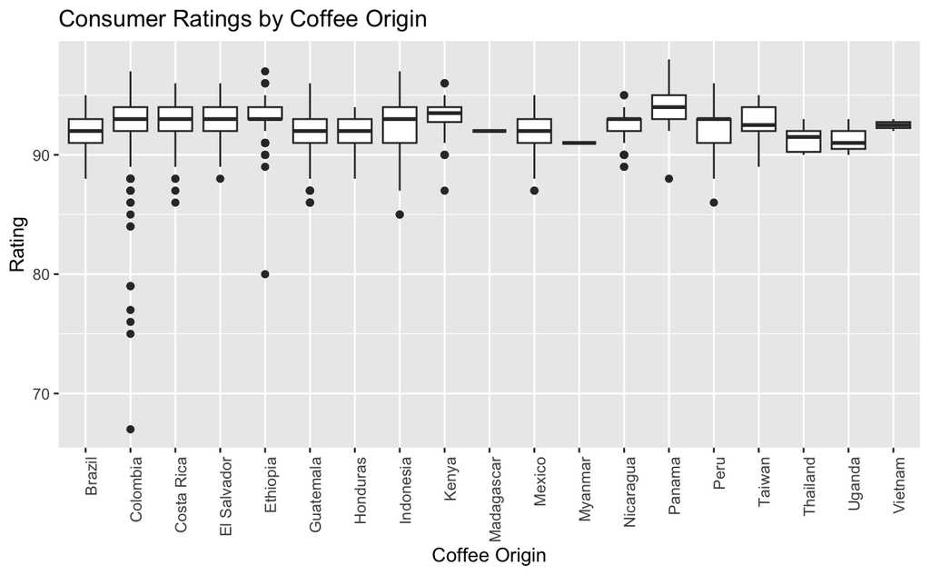

```r
#Boxplot for Ratings by Coffee Origin
ggplot(coffee_reviews_price_clean, aes(x = `coffee_origin`, y = rating)) +
  geom_boxplot() +
  labs(title = "Consumer Ratings by Coffee Origin", x = "Coffee Origin", y = "Rating") +
  theme(axis.text.x = element_text(angle = 90, hjust = 1))
```

## 5. Graphs and Further Analysis

### Graph 1: Explore the relationship between Acidity of coffee and Total Cup Points from the data set 1

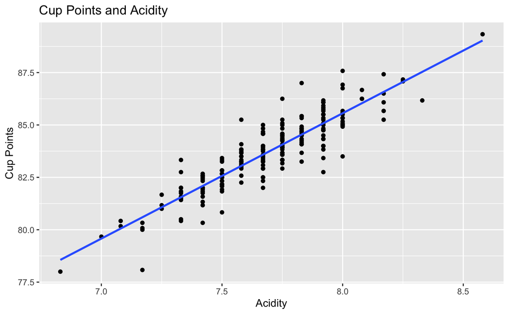

```r
ggplot(coffee_quality, aes(x = Acidity, y = `Total Cup Points`)) +
  geom_point() +
  geom_smooth(method = "lm", se = FALSE) +
  labs(title = "Cup Points and Acidity", x = "Acidity", y = "Cup Points")
```

### Graph 2: Distribution of Consumer Ratings by Origin from Dataset 2

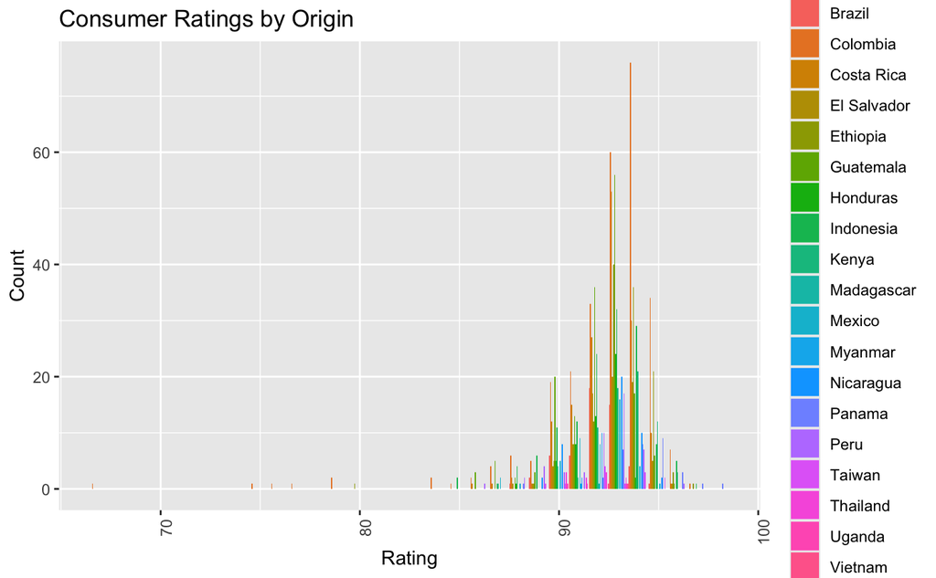

```r
ggplot(coffee_reviews_price_clean, aes(x = rating, fill = coffee_origin)) +
  geom_histogram(binwidth = 1, position = "dodge") +
  labs(title = "Consumer Ratings by Origin", x = "Rating", y = "Count") +
  theme(axis.text.x = element_text(angle = 90, hjust = 1))
```

### Graph 3: Estimated Price by Coffee Origin

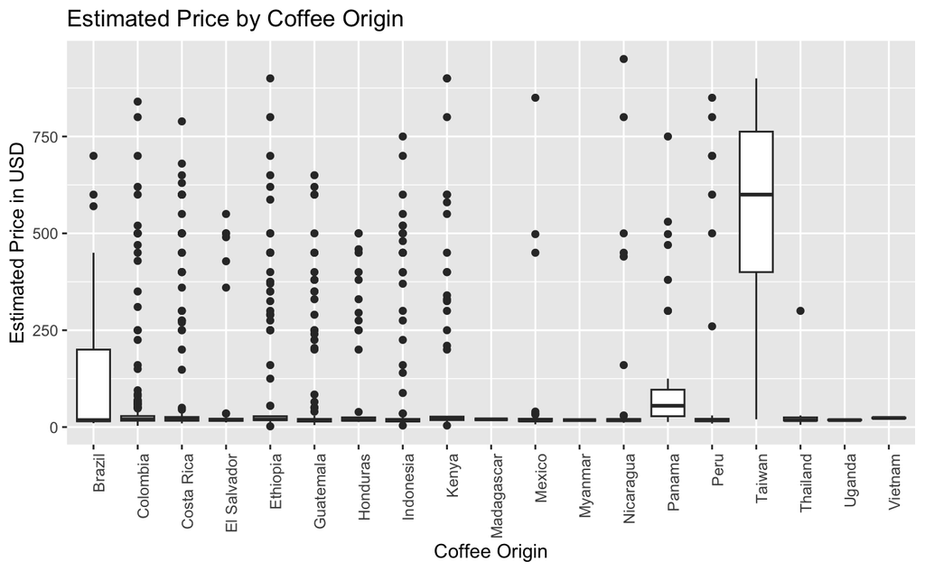

```r
ggplot(coffee_reviews_price_clean, aes(x = coffee_origin, y = est_price_numeric)) +
  geom_boxplot() +
  labs(title = "Estimated Price by Coffee Origin", x = "Coffee Origin", y = "Estimated Price in USD") +
  theme(axis.text.x = element_text(angle = 90, hjust = 1))
```

## 6. Joining Dataset and Final Plots

```r
#join data sets on the coffee origin
combined_data <- coffee_quality %>%
  inner_join(coffee_reviews_price_clean, by = c("Country of Origin" = "coffee_origin"))
head(combined_data)
```

| ...1 | ID | Country of Origin | Farm Name | Lot Number | Mill | ICO Number | Company | Altitude | Region | Producer | Number of Bags | Bag Weight | In-Country Partner | Harvest Year | Grading Date | Owner | Variety | Status | Processing Method | Aroma | Flavor | Aftertaste | Acidity | Body | Balance | Uniformity | Clean Cup | Sweetness | Overall | … |
| --- | --- | --- | --- | --- | --- | --- | --- | --- | --- | --- | --- | --- | --- | --- | --- | --- | --- | --- | --- | --- | --- | --- | --- | --- | --- | --- | --- | --- | --- | --- |
| 0 | 0 | Colombia | Finca El Paraiso | CQU2022015 | Finca El Paraiso | NA | Coffee Quality Union | 1700-1930 | Piendamo,Cauca | Diego Samuel Bermudez | 1 | 35 kg | Japan Coffee Exchange | 2021 / 2022 | September 21st, 2022 | Coffee Quality Union | Castillo | Completed | Double Anaerobic Washed | 8.58 | 8.5 | 8.42 | 8.58 | 8.25 | 8.42 | 10 | 10 | 10 | 8.58 | … |
| 0 | 0 | Colombia | Finca El Paraiso | CQU2022015 | Finca El Paraiso | NA | Coffee Quality Union | 1700-1930 | Piendamo,Cauca | Diego Samuel Bermudez | 1 | 35 kg | Japan Coffee Exchange | 2021 / 2022 | September 21st, 2022 | Coffee Quality Union | Castillo | Completed | Double Anaerobic Washed | 8.58 | 8.5 | 8.42 | 8.58 | 8.25 | 8.42 | 10 | 10 | 10 | 8.58 | … |
| 0 | 0 | Colombia | Finca El Paraiso | CQU2022015 | Finca El Paraiso | NA | Coffee Quality Union | 1700-1930 | Piendamo,Cauca | Diego Samuel Bermudez | 1 | 35 kg | Japan Coffee Exchange | 2021 / 2022 | September 21st, 2022 | Coffee Quality Union | Castillo | Completed | Double Anaerobic Washed | 8.58 | 8.5 | 8.42 | 8.58 | 8.25 | 8.42 | 10 | 10 | 10 | 8.58 | … |
| 0 | 0 | Colombia | Finca El Paraiso | CQU2022015 | Finca El Paraiso | NA | Coffee Quality Union | 1700-1930 | Piendamo,Cauca | Diego Samuel Bermudez | 1 | 35 kg | Japan Coffee Exchange | 2021 / 2022 | September 21st, 2022 | Coffee Quality Union | Castillo | Completed | Double Anaerobic Washed | 8.58 | 8.5 | 8.42 | 8.58 | 8.25 | 8.42 | 10 | 10 | 10 | 8.58 | … |
| 0 | 0 | Colombia | Finca El Paraiso | CQU2022015 | Finca El Paraiso | NA | Coffee Quality Union | 1700-1930 | Piendamo,Cauca | Diego Samuel Bermudez | 1 | 35 kg | Japan Coffee Exchange | 2021 / 2022 | September 21st, 2022 | Coffee Quality Union | Castillo | Completed | Double Anaerobic Washed | 8.58 | 8.5 | 8.42 | 8.58 | 8.25 | 8.42 | 10 | 10 | 10 | 8.58 | … |
| 0 | 0 | Colombia | Finca El Paraiso | CQU2022015 | Finca El Paraiso | NA | Coffee Quality Union | 1700-1930 | Piendamo,Cauca | Diego Samuel Bermudez | 1 | 35 kg | Japan Coffee Exchange | 2021 / 2022 | September 21st, 2022 | Coffee Quality Union | Castillo | Completed | Double Anaerobic Washed | 8.58 | 8.5 | 8.42 | 8.58 | 8.25 | 8.42 | 10 | 10 | 10 | 8.58 | … |

```r
NA
```

### 1. Scatter Plot: Cup Points vs Consumer Ratings

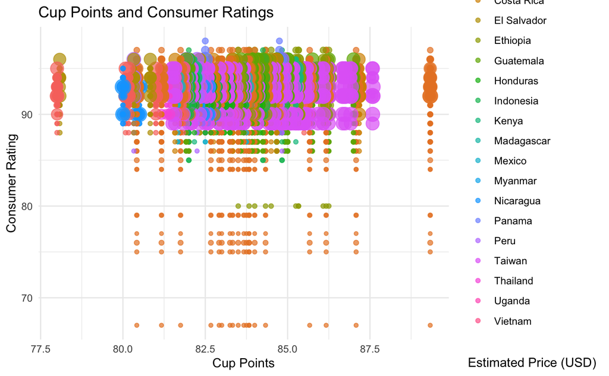

```r
ggplot(combined_data, aes(x = `Total Cup Points`, y = rating, color = `Country of Origin`, size = est_price_numeric)) +
  geom_point(alpha = 0.7) +
  labs(title = "Cup Points and Consumer Ratings",
       x = "Cup Points",
       y = "Consumer Rating",
       color = "Coffee Origin",
       size = "Estimated Price (USD)") +
  theme_minimal()
```

### 2. Box Plot: Consumer Ratings by Coffee Origin

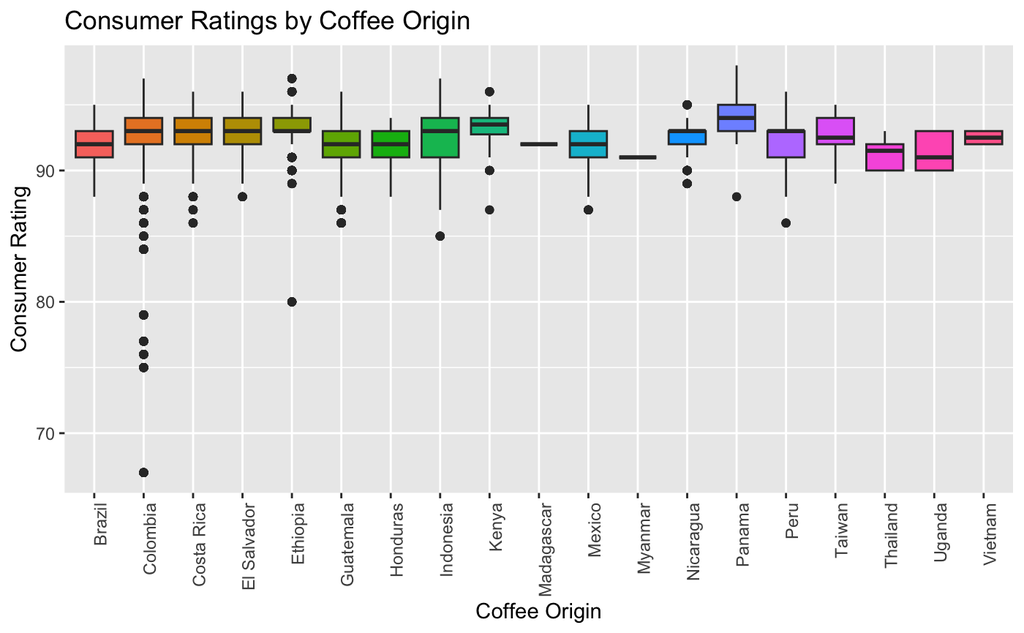

```r
ggplot(combined_data, aes(x = `Country of Origin`, y = rating, fill = `Country of Origin`)) +
  geom_boxplot() +
  labs(title = "Consumer Ratings by Coffee Origin",
       x = "Coffee Origin",
       y = "Consumer Rating") +
  theme(axis.text.x = element_text(angle = 90, hjust = 1),
        legend.position = "none")
```

### 3, Box Plot: Price by Coffee Origin

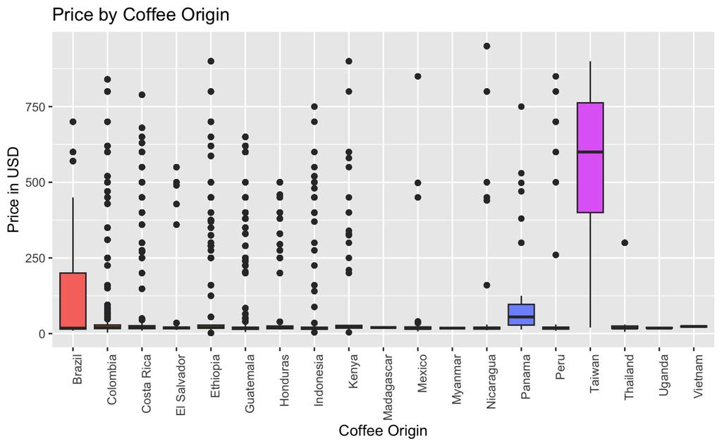

```r
ggplot(combined_data, aes(x = `Country of Origin`, y = est_price_numeric, fill = `Country of Origin`)) +
  geom_boxplot() +
  labs(title = "Price by Coffee Origin",
       x = "Coffee Origin",
       y = "Price in USD") +
  theme(axis.text.x = element_text(angle = 90, hjust = 1),
        legend.position = "none")
```

### 4. Combined Bar Plot for Average Consumer Ratings, Total Cup Points, and Estimated Prices

```r
#calculate average values by coffee origin
avg_data <- combined_data %>%
  group_by(`Country of Origin`) %>%
  summarise(avg_rating = mean(rating, na.rm = TRUE),
            avg_cup_points = mean(`Total Cup Points`, na.rm = TRUE),
            avg_price = mean(est_price_numeric, na.rm = TRUE))

head(avg_data)
```

| Country of Origin | avg_rating | avg_cup_points | avg_price |
| --- | --- | --- | --- |
| Brazil | 91.96226 | 81.88300 | 117.96547 |
| Colombia | 92.34296 | 83.87737 | 52.61433 |
| Costa Rica | 92.56209 | 83.74000 | 97.13523 |
| El Salvador | 92.71053 | 81.53286 | 54.46789 |
| Ethiopia | 93.24219 | 84.96091 | 109.22578 |
| Guatemala | 91.99383 | 84.30143 | 63.36772 |

[figure not shown]

```r
#reshape for the plot
avg_data_long <- avg_data %>%
  pivot_longer(cols = c(avg_rating, avg_cup_points, avg_price),
               names_to = "metric",
               values_to = "value")

ggplot(avg_data_long, aes(x = reorder(`Country of Origin`, value), y = value, fill = metric)) +
  geom_bar(stat = "identity", position = position_dodge()) +
  labs(title = "Average Consumer Ratings, Total Cup Points, and Estimated Prices by Coffee Origin",
       x = "Coffee Origin",
       y = "Average Value") +
  theme_minimal() +
  theme(axis.text.x = element_text(angle = 90, hjust = 1)) +
  scale_fill_manual(values = c("avg_rating" = "skyblue", "avg_cup_points" = "lightgreen", "avg_price" = "orange"),
                    name = "Metric",
                    labels = c("Average Rating", "Average Cup Points", "Average Price in USD"))
```

## Conclusion

This research and analysis explored the relationship between professional coffee scores (Total Cup Points), consumer ratings, and prices for coffee beans from different origins.

### Total Cup Points and Consumer Ratings:

The distribution of Total Cup Points shows that most coffee samples scored between 80 and 85 points. Consumer ratings are skewed to the higher end, with the majority of ratings are around 90 points.

### Estimated Price by Coffee Origin:

The estimated price of coffee varies by origin, with some origins having much higher prices. Coffee from Taiwan tends to have higher average prices.

There is no clear relationship between the price and the Total Cup Points or Consumer Ratings, showing that other factors like rarity, production costs and market demand play a role in the price.

### Analysis of Coffee Origins:

A comparison of average ratings, Total Cup Points, and prices for different coffee origins showing that some origins like Ethiopia and Colombia consistently perform well in both professional and consumer evaluations, but others like Taiwan are valued more for their high prices even though they have moderate ratings.

This suggests that geographical branding and the market are impacting consumer choices and pricing.

## Addressing the Research Question

### Price:

The price of coffee is not only associated with the quality. Instead, prices are influenced by a combination of factors including reputation, market, and possibly marketing.